# Florida Medical Professional Liability

*This file contains illustrative **R** code for fitting Copula. The idea is to have a basic framework for fitting Copula to Data. We start with simulated data and then use the framework to fit Copula to real data.*

# 1 Data

```r
SampleData <- read.csv("FloridaMPLExcess2MM.csv", header=T, na.strings=c("."), stringsAsFactors=FALSE)
```

## 1.1 Summary Statistics

A few values of Loss Adjustment were coded as less than 10. These are replaced with zeros.

```r
Vars <- c("IndemnityPaid", "LossAdjustment", "NonEconomicLoss", "InjurySeverity","InsurerType",
          "CountyInjuryOccurred","FinalDisposition","CourtDecision","DateInjuryOccurred","DateInjuryReported")
Data <- SampleData[Vars]
#sum(1*(Data$LossAdjustment>0)*(Data$LossAdjustment<10))
Data$LossAdjustment <- Data$LossAdjustment*(Data$LossAdjustment>10)
#sum(1*(Data$NonEconomicLoss>0)*(Data$NonEconomicLoss<10))
scalefactor <- 1000
Data$IndemnityPaid   <- Data$IndemnityPaid/scalefactor
Data$LossAdjustment  <- Data$LossAdjustment/scalefactor
Data$NonEconomicLoss <- Data$NonEconomicLoss/scalefactor
cnames <- c("Y1", "Y2", "Y3", "x1","x2","x3","x4","x5","Date1","Date2")
Data1 <- Data
colnames(Data1) <- cnames
Data1$PosY2 <- 1*(Data1$Y2>0)
Data1$PosY3 <- 1*(Data1$Y3>0)
```

### 1.1.1 Dependent Variables

```r
summ2 <- cbind(summary(Data[,1]),summary(Data[,2]),summary(Data[,3]))
colnames(summ2) <- c("Indemnity Paid", "Loss Adjustment", "NonEconomic Loss")
knitr::kable(summ2,digits=0, caption="Dependent Variable Summary Measures")
```

Dependent Variable Summary Measures

|  | Indemnity Paid | Loss Adjustment | NonEconomic Loss |
| --- | --- | --- | --- |
| Min. | 2000 | 0 | 0 |
| 1st Qu. | 2400 | 27 | 0 |
| Median | 3100 | 106 | 0 |
| Mean | 7107 | 526 | 1160 |
| 3rd Qu. | 5000 | 255 | 1500 |
| Max. | 750000 | 149300 | 56200 |

There are 86 zeros for *Y2 = LossAdjustment* and 374 zeros for *Y3 = NonEconomicLoss*. Here is a table of their joint behavior

```r
table(Data1$PosY2,Data1$PosY3)
```

```
##
##       0   1
##   0  78   8
##   1 296 264
```

The variable *IndemnityPaid* has long tails. There are 14 claims in excess of $25 MM. They are

```r
Bigdata$IndemnityPaid[order(Bigdata$IndemnityPaid)]
```

```
##  [1]  28637.86  29750.00  35000.00  40000.00  42308.33  42500.00  48656.94
##  [8]  61942.03  70000.00 141129.05 145000.00 195000.00 230000.00 749999.75
```

Note that the largest claims is 749.99975 in millions of USD.

The distribution of these three dependent variables are skewed. Here are summaries of the distribution (after removing zeros from Y2 and Y3).

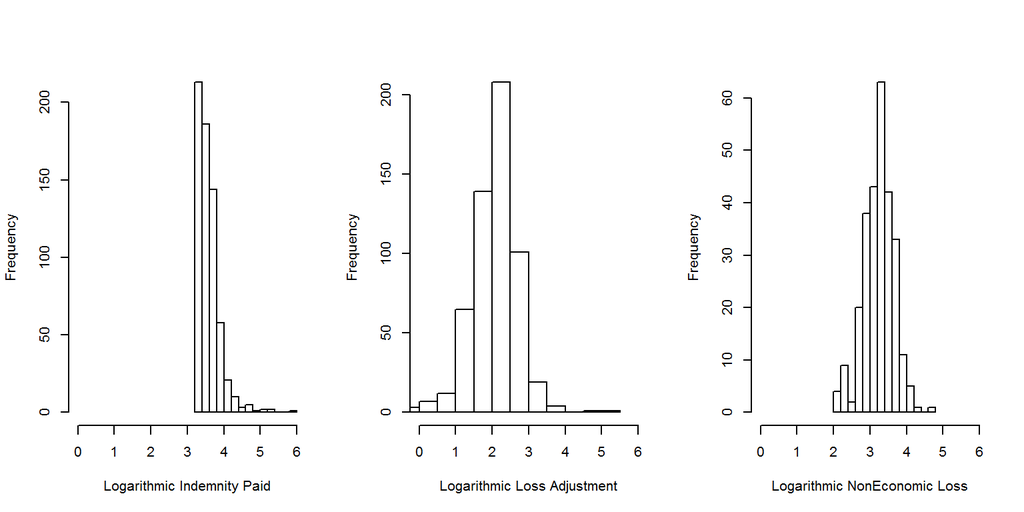

```r
PosY2data <- subset(Data1, Y2>0)
PosY3data <- subset(Data1, Y3>0)
par(mfrow=c(1,3))
hist(log10(Data1$Y1), xlab = "Logarithmic Indemnity Paid", main="", xlim=c(0,6))
hist(log10(PosY2data$Y2), xlab = "Logarithmic Loss Adjustment", main="", xlim=c(0,6))
hist(log10(PosY3data$Y3), xlab = "Logarithmic NonEconomic Loss", main="", xlim=c(0,6))
```

```r
SumY1 <- summary(Data1$Y1)
SumY2 <- summary(PosY2data$Y2)
SumY3 <- summary(PosY3data$Y3)
SummaryY <- cbind(SumY1,SumY2,SumY3)
colnames(SummaryY) <- c("Indemnity Paid", "Loss Adjustment", "NonEconomic Loss")
knitr::kable(SummaryY,digits=1, caption="Dependent Variable Summary Measures, Omitting Zeros")
```

Dependent Variable Summary Measures, Omitting Zeros

|  | Indemnity Paid | Loss Adjustment | NonEconomic Loss |
| --- | --- | --- | --- |
| Min. | 2000 | 0.4 | 100 |
| 1st Qu. | 2400 | 54.0 | 1000 |
| Median | 3100 | 136.7 | 2000 |
| Mean | 7107 | 607.3 | 2754 |
| 3rd Qu. | 5000 | 293.0 | 3000 |
| Max. | 750000 | 149300.0 | 56200 |

### 1.1.2 Explanatory Variables

These variables do not help on claims prediction but may help explain claim size. Will need to incorporate the two date variables later.

```r
table(Data[,4]); table(Data[,5]); table(Data[,7]);table(Data[,8])
```

```
##
##                                                          Emotional Only - Fright, no physical damage
##                                                                                                    4
##                                                                                    Permanent: Death.
##                                                                                                  128
##              Permanent: Grave - Quadraplegia, severe brain damage, lifelong care or fatal prognosis.
##                                                                                                  213
##                           Permanent: Major - Paraplegia, blindness, loss of two limbs, brain damage.
##                                                                                                  207
##      Permanent: Minor - Loss of fingers, loss or damage to organs.  Includes non-disabling injuries.
##                                                                                                   21
##            Permanent: Significant - Deafness, loss of limb, loss of eye, loss of one kidney or lung.
##                                                                                                   53
## Temporary: Major - Burns, surgical material left, drug side effect, brain damage.  Recovery delayed.
##                                                                                                   14
##                  Temporary: Minor - Infections, misset fracture, fall in hospital. Recovery delayed.
##                                                                                                    5
##                           Temporary: Slight - Lacerations, contusions, minor scars, rash.  No delay.
##                                                                                                    1
```

```
##
##     Licensed Self-Insurer
##          355          291
```

```
##
## Disposed of by Court   Settled by parties
##                   31                  615
```

```
##
##                     Directed verdict for plaintiff.
##                                                  12
##                         Judgment for the defendant.
##                                                   1
##         Judgment for the plaintiff after appeal ...
##                                                   7
##                         Judgment for the plaintiff.
##                                                  51
## Judgment notwithstanding the verdict for plaintiff.
##                                                   3
##                               No Court Proceedings.
##                                                 539
##                                               Other
##                                                  33
```

Claims by County

```r
table(Data[,6])
```

```
##
##                   Alachua          Bay      Brevard      Broward
##          218            2            2            6           42
##    Charlotte       Citrus         Clay      Collier     Columbia
##            3            1            4            1            2
##         Dade        Duval     Escambia      Gadsden       Hardee
##          118           14            1            1            1
##     Hernando    Highlands Hillsborough Indian River      Jackson
##            2            3           34            4            1
##    Jefferson         Lake          Lee         Leon      Manatee
##            1            4            5            4            7
##       Marion       Martin       Monroe       Nassau   Okeechobee
##            2            2            2            1            1
##       Orange      Osceola Out of state   Palm Beach        Pasco
##           32            1           15           37            8
##     Pinellas         Polk     Sarasota     Seminole    St. Johns
##           27            7            1           11            2
##    St. Lucie      Volusia   Washington
##            5           10            1
```

## 1.2 Relationships

The most interesting variable is **x2**. Self-insurers pay loss adjustment expenses and non-economic damages less often than claims insured by licensed carriers.

```r
Tablexj<-function(xj1, xj2, xj3) {
#  xj1=Data1$x1;xj2=PosY2data$x1;xj3=PosY3data$x1)
r1 <- aggregate(Y1   ~ xj1, data=Data1,    length)$Y1
r2 <- aggregate(Y1   ~ xj1, data=Data1,    mean)$Y1
r3 <- aggregate(Y1   ~ xj1, data=Data1,    median)$Y1
r4 <- aggregate(PosY2~ xj1, data=Data1,    mean)$PosY2
r5 <- aggregate(Y2   ~ xj2, data=PosY2data,median)$Y2
r5star = r4;rcount=1
for (i in 1:length(r1)){
  if (r4[i] ==0)  r5star[i]<-"NA" else r5star[i]=r5[rcount]
  rcount=rcount+1}
r6 <- aggregate(PosY3~ xj1, data=Data1,    mean)$PosY3
r7 <- aggregate(Y3   ~ xj3, data=PosY3data,median)$Y3
r7star = r6;rcount=1
for (i in 1:length(r1)){
  if (r6[i]==0) r7star[i]<-"NA" else r7star[i]<-r7[rcount]
  rcount=rcount+1}
cbind(r1,r2,r3,r4,as.numeric(r5star),r6,as.numeric(r7star))
}
t1 <- Tablexj(Data1$x1,PosY2data$x1,PosY3data$x1)
t2 <- Tablexj(Data1$x2,PosY2data$x2,PosY3data$x2)
#t3 <- Tablexj(Data1$x3,PosY2data$x3,PosY3data$x3)
t4 <- Tablexj(Data1$x4,PosY2data$x4,PosY3data$x4)
t5 <- Tablexj(Data1$x5,PosY2data$x5,PosY3data$x5)
rownames(t1) <- c("x1:Emotional","x1:Permanent:Death","x1:Permanent:Grave","x1:Permanent:Major","x1:Permanent:Minor","x1:Permanent:Significant",
                  "x1:Temporary:Major","x1:Temporary:Minor", "x1:Temporary:Slight")
rownames(t2) <- c("x2:Licensed","x2:Self-Insurer")
rownames(t4) <- c("x4:Disposed of by Court","x4:Settled by parties")
rownames(t5) <- c("x5:Directed verdict for plaintiff","x5:Judgment for the defendant","x5:Judgment for the plaintiff after appeal",
                  "x5:Judgment for the plaintiff","x5:Judgment notwithstanding the verdict for plaintiff",
                  "x5:No Court Proceedings","x5:Other")
#TableMat <- rbind(t1,t2,t3,t4,t5)
TableMat <- rbind(t1,t2,t4,t5)
colnames(TableMat) <-  c("Num Obs","Mean Y1","Median Y1","Prop Y2","Median Pos Y2","Prop Y3", "Median Pos Y3")
knitr::kable(TableMat,digits=3, caption="Explanatory Variables")
```

Explanatory Variables

|  | Num Obs | Mean Y1 | Median Y1 | Prop Y2 | Median Pos Y2 | Prop Y3 | Median Pos Y3 |
| --- | --- | --- | --- | --- | --- | --- | --- |
| x1:Emotional | 4 | 5275.000 | 2050.000 | 1.000 | 273.355 | 0.750 | 1000.000 |
| x1:Permanent:Death | 128 | 7236.343 | 2725.000 | 0.828 | 104.049 | 0.398 | 2050.000 |
| x1:Permanent:Grave | 213 | 8800.772 | 3500.000 | 0.878 | 135.024 | 0.455 | 2000.000 |
| x1:Permanent:Major | 207 | 5483.165 | 3400.000 | 0.903 | 156.096 | 0.372 | 2000.000 |
| x1:Permanent:Minor | 21 | 4921.370 | 3103.978 | 0.762 | 91.434 | 0.524 | 2100.000 |
| x1:Permanent:Significant | 53 | 4047.308 | 2600.000 | 0.811 | 177.463 | 0.528 | 1825.000 |
| x1:Temporary:Major | 14 | 21397.403 | 3400.000 | 0.857 | 112.141 | 0.286 | 1400.000 |
| x1:Temporary:Minor | 5 | 2159.341 | 2145.150 | 0.800 | 49.988 | 0.200 | 2145.150 |
| x1:Temporary:Slight | 1 | 5750.000 | 5750.000 | 1.000 | 325.000 | 0.000 | NA |
| x2:Licensed | 355 | 8568.982 | 3375.000 | 0.927 | 148.913 | 0.682 | 2000.000 |
| x2:Self-Insurer | 291 | 5322.712 | 3000.000 | 0.794 | 116.510 | 0.103 | 2638.370 |
| x4:Disposed of by Court | 31 | 5187.719 | 3103.978 | 0.871 | 255.166 | 0.613 | 2579.939 |
| x4:Settled by parties | 615 | 7203.380 | 3100.000 | 0.867 | 131.743 | 0.411 | 2000.000 |
| x5:Directed verdict for plaintiff | 12 | 3426.543 | 3103.978 | 0.750 | 202.540 | 0.417 | 1500.000 |
| x5:Judgment for the defendant | 1 | 28637.859 | 28637.859 | 1.000 | 1479.505 | 1.000 | 8000.000 |
| x5:Judgment for the plaintiff after appeal | 7 | 4682.216 | 2142.834 | 1.000 | 277.711 | 0.714 | 4700.000 |
| x5:Judgment for the plaintiff | 51 | 7084.970 | 3375.000 | 0.922 | 279.296 | 0.588 | 3125.000 |
| x5:Judgment notwithstanding the verdict for plaintiff | 3 | 4335.952 | 5005.000 | 1.000 | 212.978 | 0.333 | 5005.000 |
| x5:No Court Proceedings | 539 | 7189.637 | 3000.000 | 0.866 | 120.000 | 0.406 | 1650.000 |
| x5:Other | 33 | 7236.674 | 4500.000 | 0.788 | 306.922 | 0.333 | 3559.910 |

```r
CorMat <- cor(Data[,1:3], method="spearman", use="pairwise.complete.obs")
knitr::kable(CorMat,digits=3, caption="Spearman Correlations")
```

Spearman Correlations

|  | IndemnityPaid | LossAdjustment | NonEconomicLoss |
| --- | --- | --- | --- |
| IndemnityPaid | 1.000 | 0.200 | 0.108 |
| LossAdjustment | 0.200 | 1.000 | 0.243 |
| NonEconomicLoss | 0.108 | 0.243 | 1.000 |

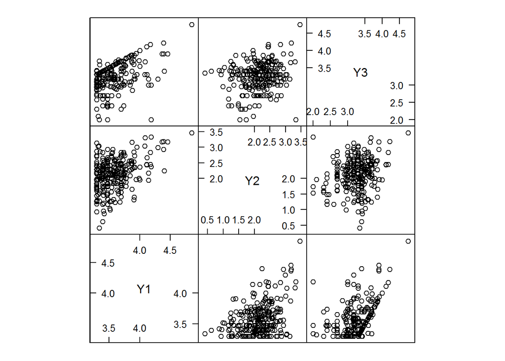

```r
library(copula)
DataComplete <- subset(Data1, Y2>0 & Y3>0)
splom2(log10(DataComplete[,1:3]), cex=0.8, col.mat="black")
```

```r
#What is the relationship between indemnity paid and non-economic losses???
sum((DataComplete$Y1<DataComplete$Y3))
```

```
## [1] 8
```

```r
sum((DataComplete$Y1==DataComplete$Y3))
```

```
## [1] 81
```

```r
sum((DataComplete$Y1>DataComplete$Y3))
```

```
## [1] 175
```